# A short introduction to compression with MGARD

## A short introduction to compression with MGARD

```python
import numpy as np
import matplotlib.pyplot as plt
import numpy.linalg as la
```

```python
def max_rerror(u0, u):
    return (np.abs(u0-u).max()/np.abs(u0).max())
```

```python
def max_error(u0, u):
    return (np.abs(u0-u).max())
```

```python
def franke(x1, x2, x3):
    term1 = 0.75 * np.exp(-(9*x1-2)**2/4 - (9*x2-2)**2/4);
    term2 = 0.75 * np.exp(-(9*x1+1)**2/49 - (9*x2+1)/10);
    term3 = 0.5 * np.exp(-(9*x1-7)**2/4 - (9*x2-3)**2/4);
    term4 = -0.2 *np.exp(-(9*x1-4)**2 - (9*x2-7)**2);

    return ( x3 + term1 + term2 + term3 + term4)
```

```python
data_dir = "/home/user/share/build/tmp/MGARD/"
```

First let's load examine our data file:

```python
data_orig = np.fromfile(data_dir + "data.bin")
```

```python
u = data_orig.reshape((64, 64, 64))
```

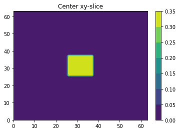

```python
plt.title("Center xy-slice")
plt.contourf(u[:,:,32])
plt.colorbar()
```

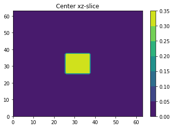

```python
plt.title("Center xz-slice")
plt.contourf(u[:,32,:])
plt.colorbar()
```

Data consists of concentric cubes, where most of the outer region is equal zero. Whic is evideng from the 1-D plot below

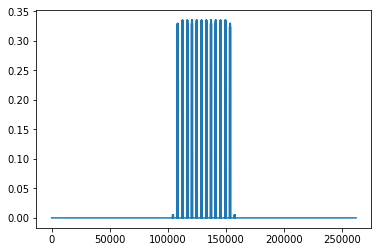

```python
plt.plot(in_file)
```

Now let's compress this data while preserving the relative $ L_\infty $ error. The relevant call to MGARD compressor in this case will be:

- mgard_compress(iflag, v.data(), out_size, nrow, ncol, nfib, tol);

  ** Here iflag is the data type (0-> float, 1-> double)

  ** v is the input data

  ** nrow, ncol, nfib : Dimension of input

  ** tol: The tolerance in $ L_\infty $ norm

  MGARD will return a pointer to the compressed data (unsigned char*) and the output size; out_size

Let's pick a tolerance of $10^{-3}$ and compress our data, decompress it and see what has happens.

```python
comp_data = np.fromfile(data_dir + "data_0.001000_infty.dat")
```

```python
ut_inf_m3 = comp_data.reshape((64,64,64))
```

Let's check the error

```python
max_error(u, ut_inf_m3)
```

```
0.0005609203671535953
```

It seems the tolerance is met! Good. What if we wanted to preserve the error in derivative, say $\partial_x$? Then we call MGARD in the following manner:

- mgard_compress(iflag, v.data(), out_size, nrow, ncol, nfib, tol, s); with s = 1

```python
comp_data = np.fromfile(data_dir + "data_1e-7_s1.dat")
```

```python
ut_s1_m7 = comp_data.reshape((64,64,64))
```

Let's compute the derivatives:

```python
dux  = np.gradient(u, axis=0)
dutx = np.gradient(ut_s1_m7, axis=0)
```

```python
max_error(dux, dutx)
```

```
6.847788780461883e-09
```

Good, the tolerance holds! Let's see how the deriative looks like on the center:

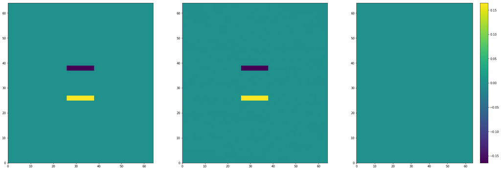

```python
v_min = dux.min()
v_max = dux.max()

fig = plt.figure(figsize=(30,10));
ax = fig.add_subplot(1,3, 1)
cx = ax.pcolor(dux[:,:,32], cmap='viridis',
                   vmin=v_min, vmax=v_max)

ax = fig.add_subplot(1,3, 2)
cx = ax.pcolor(dutx[:,:,32],cmap='viridis',
                   vmin=v_min, vmax=v_max )

ax = fig.add_subplot(1,3, 3)
cx = ax.pcolor(np.abs(dux[:,:,32] - dutx[:,:,32]),cmap='viridis',
                   vmin=v_min, vmax=v_max)

plt.colorbar(cx);
```

```python
x = np.linspace(-1,1,71)
x1, x2, x3 = np.meshgrid(x,x,x)
ufz = franke(x1, x2, x3)
```

```python
ufz.tofile(data_dir + "franke3.bin")
```

```python
ff = np.fromfile(data_dir + "franke3_0.010000_infty.dat")
```

$L_{\infty}$ compression, $\tau = 10^{-2}$

```python
utfz = ff.reshape((71, 71, 71))
```

```python
dufz  = np.gradient(ufz, axis=0)
dutfz = np.gradient(utfz, axis=0)
```

```python
max_rerror(np.gradient(ufz, axis=0), np.gradient(utfz, axis=0))
```

```
0.07376693520536426
```

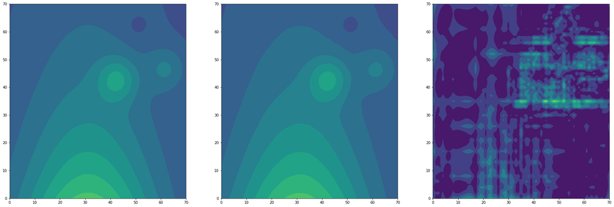

```python
v_min = ufz.min()
v_max = ufz.max()

fig = plt.figure(figsize=(30,10));
ax = fig.add_subplot(1,3, 1)
cx = ax.contourf(ufz[:,:,32], cmap='viridis',
                   vmin=v_min, vmax=v_max)

ax = fig.add_subplot(1,3, 2)
cx = ax.contourf(utfz[:,:,32],cmap='viridis',
                   vmin=v_min, vmax=v_max )

ax = fig.add_subplot(1,3, 3)
ax.contourf(np.abs(ufz[:,:,32] - utfz[:,:,32]),cmap='viridis')

#plt.colorbar(cx);
```

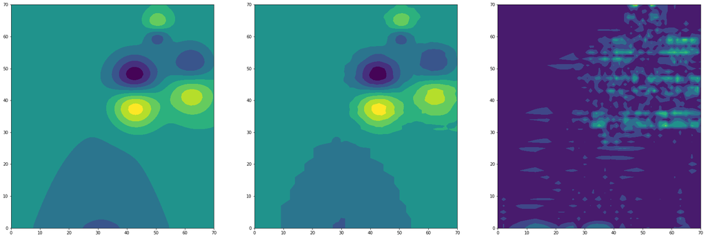

```python
v_min = dufz.min()
v_max = dufz.max()

fig = plt.figure(figsize=(30,10));
ax = fig.add_subplot(1,3, 1)
cx = ax.contourf(dufz[:,:,32], cmap='viridis', vmin=v_min, vmax=v_max)

ax = fig.add_subplot(1,3, 2)
cx = ax.contourf(dutfz[:,:,32],cmap='viridis', vmin=v_min, vmax=v_max )

ax = fig.add_subplot(1,3, 3)
ax.contourf(np.abs(dufz[:,:,32] - dutfz[:,:,32]),cmap='viridis')

#plt.colorbar(cx);
```

S1 compression, $\tau = 10^{-2}$

```python
fs1 = np.fromfile(data_dir + "franke3_0.010000_s1.dat")
```

```python
utfzs1 = fs1.reshape((71, 71, 71))
```

```python
dutfzs1 = np.gradient(utfzs1, axis=0)
```

```python
max_rerror(np.gradient(ufz, axis=0), np.gradient(utfzs1, axis=0))
```

```
0.005602861419883853
```

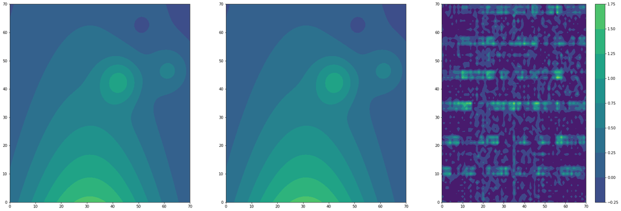

```python
v_min = ufz.min()
v_max = ufz.max()

fig = plt.figure(figsize=(30,10));
ax = fig.add_subplot(1,3, 1)
cx = ax.contourf(ufz[:,:,32], cmap='viridis',
                   vmin=v_min, vmax=v_max)

ax = fig.add_subplot(1,3, 2)
cx = ax.contourf(utfzs1[:,:,32],cmap='viridis',
                   vmin=v_min, vmax=v_max )

ax = fig.add_subplot(1,3, 3)
ax.contourf(np.abs(ufz[:,:,32] - utfzs1[:,:,32]),cmap='viridis',
                  )

plt.colorbar(cx);
```

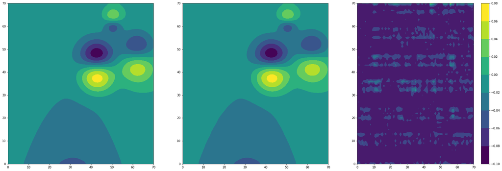

```python
v_min = dufz.min()
v_max = dufz.max()

fig = plt.figure(figsize=(30,10));
ax = fig.add_subplot(1,3, 1)
cx = ax.contourf(dufz[:,:,32], cmap='viridis',
                   vmin=v_min, vmax=v_max)

ax = fig.add_subplot(1,3, 2)
cx = ax.contourf(dutfzs1[:,:,32],cmap='viridis',
                   vmin=v_min, vmax=v_max )

ax = fig.add_subplot(1,3, 3)
ax.contourf(np.abs(dufz[:,:,32] - dutfzs1[:,:,32]),cmap='viridis',
                   )

plt.colorbar(cx);
```